# ProsperLoan_Exploration_Part2 slides

##### Summary of Key Insights

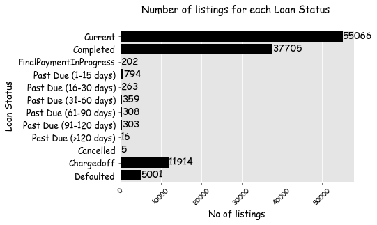

```
{'tags': ['to_remove'], 'slideshow': {'slide_type': 'fragment'}}
```

- *Current and Completed listings constitutes over 70% of the total listings, this concludes that Prosper Loan company has a very good risk management system.*

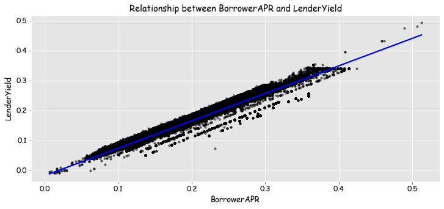

```
{'tags': ['to_remove'], 'slideshow': {'slide_type': 'fragment'}}
```

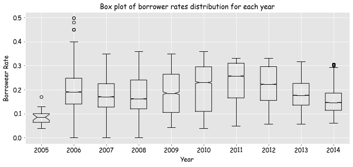

```
{'tags': ['to_remove'], 'slideshow': {'slide_type': 'fragment'}}
```

- *2006 saw the highest borrower rate of about 0.5*
- *There is a left skewed distribution of borrower rates in 2010, 2011, and 2012, i.e most values are less than the median*
- *There is a right skewed distribution of borrower rates in 2014, i.e most values are greater than the median*
- *The distribution in borrower rates for other years are normal*

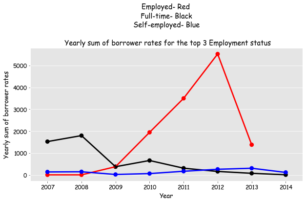

```
{'tags': ['to_remove'], 'slideshow': {'slide_type': 'fragment'}}
```

- *The yearly sum of borrower rates for Full-time workers decreased with time*
- *The yearly sum of borrower rates for self-employed workers went about on a close range (from about 20 to 300)*
- *The yearly sum of borrower rates for employed workers increased with time until 2013 which saw a great depreciation*

```
[NbConvertApp] Converting notebook ProsperLoan_Exploration_Part2.ipynb to slides
[NbConvertApp] Writing 781231 bytes to ProsperLoan_Exploration_Part2.slides.html
```